# Predicting house prices using k-nearest neighbors regression

In this notebook, you will implement k-nearest neighbors regression. You will:

- Find the k-nearest neighbors of a given query input
- Predict the output for the query input using the k-nearest neighbors
- Choose the best value of k using a glbObsOOB set

# Fire up GraphLab Create

```python
import pprint
import numpy as np
import pandas as pd
import matplotlib.pyplot as plt
%matplotlib inline
import graphlab as gl
print gl.version
gl.canvas.set_target('ipynb')
from sklearn import metrics
```

```
1.8.1
```

# Load in house sales data

For this notebook, we use a subset of the King County housing dataset created by randomly selecting 40% of the houses in the full dataset.

```python
sales = gl.SFrame('data/kc_house_data_small.gl/')
```

[output not shown]

```python
print sales.shape
sales.show()
```

```
(8703, 21)
```

# Import useful functions from previous notebooks

To efficiently compute pairwise distances among data points, we will convert the SFrame into a 2D Numpy array. First import the numpy library and then copy and paste `get_numpy_data()` from the second notebook of Week 2.

```python
import numpy as np # note this allows us to refer to numpy as np instead
```

```python
def get_numpy_data(data_sframe, features, output):

    data_sframe['constant'] = 1
    features = ['constant'] + features
    features_sframe = data_sframe[features]

    feature_matrix = features_sframe.to_numpy()
    output_sarray = data_sframe[output]

    output_array = output_sarray.to_numpy()
    return(feature_matrix, output_array)
```

We will also need the `normalize_features()` function from Week 5 that normalizes all feature columns to unit norm. Paste this function below.

```python
def normalize_features(feature_matrix):
    norms = np.linalg.norm(feature_matrix, axis=0)
    print 'normalize_features: norms:'
    print norms

    normalized_features = feature_matrix / norms
    return (normalized_features, norms)
```

# Split data into glbObsFit, glbObsNew, and glbObsOOB sets

```python
(glbObsTrn, glbObsNew) = sales.random_split(.8, seed=1)
(glbObsFit, glbObsOOB) = glbObsTrn.random_split(.8, seed=1)
```

```python
print 'glbObsTrn.shape: %d x %d' % (glbObsTrn.shape[0], glbObsTrn.shape[1])
print 'glbObsFit.shape: %d x %d' % (glbObsFit.shape[0], glbObsFit.shape[1])
print 'glbObsOOB.shape: %d x %d' % (glbObsOOB.shape[0], glbObsOOB.shape[1])
print 'glbObsNew.shape: %d x %d' % (glbObsNew.shape[0], glbObsNew.shape[1])
```

```
glbObsTrn.shape: 6962 x 21
glbObsFit.shape: 5527 x 21
glbObsOOB.shape: 1435 x 21
glbObsNew.shape: 1741 x 21
```

# Extract features and normalize

Using all of the numerical inputs listed in `feature_list`, transform the glbObsFit, glbObsNew, and glbObsOOB SFrames into Numpy arrays:

```python
feature_list = ['bedrooms',
                'bathrooms',
                'sqft_living',
                'sqft_lot',
                'floors',
                'waterfront',
                'view',
                'condition',
                'grade',
                'sqft_above',
                'sqft_basement',
                'yr_built',
                'yr_renovated',
                'lat',
                'long',
                'sqft_living15',
                'sqft_lot15']
glbObsFit_feats, glbObsFit_rsp = \
    get_numpy_data(glbObsFit, feature_list, 'price')
glbObsNew_feats, glbObsNew_rsp = \
    get_numpy_data(glbObsNew, feature_list, 'price')
glbObsOOB_feats, glbObsOOB_rsp = \
    get_numpy_data(glbObsOOB, feature_list, 'price')
```

In computing distances, it is crucial to normalize features. Otherwise, for example, the `sqft_living` feature (typically on the order of thousands) would exert a much larger influence on distance than the `bedrooms` feature (typically on the order of ones). We divide each column of the glbObsFit feature matrix by its 2-norm, so that the transformed column has unit norm.

IMPORTANT: Make sure to store the norms of the features in the glbObsFit set. The features in the glbObsNew and glbObsOOB sets must be divided by these same norms, so that the glbObsFit, glbObsNew, and glbObsOOB sets are normalized consistently.

```python
glbObsFit_feats, norms = normalize_features(glbObsFit_feats) # normalize glbObsFit set features (columns)
glbObsNew_feats = glbObsNew_feats / norms # normalize glbObsNew set by glbObsFit set norms
glbObsOOB_feats = glbObsOOB_feats / norms # normalize glbObsOOB set by glbObsFit set norms
```

```
normalize_features: norms:
[  7.43437960e+01   2.57850732e+02   1.65977596e+02   1.67688695e+05
   3.11491224e+06   1.17240138e+02   6.32455532e+00   5.87962584e+01
   2.57906960e+02   5.75318173e+02   1.45365513e+05   3.90863965e+04
   1.46559338e+05   2.99361461e+04   3.53588883e+03   9.08552951e+03
   1.55531640e+05   2.46533053e+06]
```

# Compute a single distance

To start, let's just explore computing the "distance" between two given houses. We will take our **query house** to be the first house of the glbObsNew set and look at the distance between this house and the 10th house of the glbObsFit set.

```python
print glbObsNew_feats[0,:]
```

```
[ 0.01345102  0.01551285  0.01807473  0.01759212  0.00160518  0.017059    0.
  0.05102365  0.0116321   0.01564352  0.01362084  0.02481682  0.01350306
  0.          0.01345386 -0.01346927  0.01375926  0.0016225 ]
```

```python
print glbObsFit_feats[9,:]
```

```
[ 0.01345102  0.01163464  0.00602491  0.0083488   0.00050756  0.01279425
  0.          0.          0.01938684  0.01390535  0.0096309   0.
  0.01302544  0.          0.01346821 -0.01346254  0.01195898  0.00156612]
```

*QUIZ QUESTION*

What is the Euclidean distance between the query house and the 10th house of the glbObsFit set?

Note: Do not use the `np.linalg.norm` function; use `np.sqrt`, `np.sum`, and the power operator (`**`) instead. The latter approach is more easily adapted to computing multiple distances at once.

```python
def getObsDistance(obsA, obsB):
    distance = np.sqrt(np.sum((obsA - obsB) ** 2))
    return distance

print 'glbObsNew[0,:] vs. glbObsFit[9,:] distance:%0.4e' % \
    (getObsDistance(glbObsNew_feats[0,:], glbObsFit_feats[9,:]))
```

```
glbObsNew[0,:] vs. glbObsFit[9,:] distance:5.9724e-02
```

# Compute multiple distances

Of course, to do nearest neighbor regression, we need to compute the distance between our query house and *all* houses in the glbObsFit set.

To visualize this nearest-neighbor search, let's first compute the distance from our query house (`glbObsNew_feats[0]`) to the first 10 houses of the glbObsFit set (`glbObsFit_feats[0:10]`) and then search for the nearest neighbor within this small set of houses. Through restricting ourselves to a small set of houses to begin with, we can visually scan the list of 10 distances to verify that our code for finding the nearest neighbor is working.

Write a loop to compute the Euclidean distance from the query house to each of the first 10 houses in the glbObsFit set.

```python
print type(glbObsFit)
qryDistances = glbObsFit[0:10][['id']]
qryDistances.rename({'id': 'idFit'})
qryDistances['idNew'] = glbObsNew[0]['id']
qryDistances['distance'] = [getObsDistance(glbObsNew_feats[0    ,:], \
                                           glbObsFit_feats[obsIx,:]) \
                            for obsIx in xrange(qryDistances.num_rows())]
print qryDistances
```

```
<class 'graphlab.data_structures.sframe.SFrame'>
+------------+------------+-----------------+
|   idFit    |   idNew    |     distance    |
+------------+------------+-----------------+
| 7129300520 | 9297300055 |  0.060274709173 |
| 6414100192 | 9297300055 | 0.0854688114883 |
| 5631500400 | 9297300055 | 0.0614994643712 |
| 2487200875 | 9297300055 | 0.0534027397882 |
| 1954400510 | 9297300055 | 0.0584448406394 |
| 2008000270 | 9297300055 | 0.0598792151018 |
| 2414600126 | 9297300055 | 0.0546314049726 |
| 1736800520 | 9297300055 | 0.0554310832416 |
| 1794500383 | 9297300055 |  0.052383627841 |
| 3303700376 | 9297300055 | 0.0597235937167 |
+------------+------------+-----------------+
[10 rows x 3 columns]
```

*QUIZ QUESTION*

Among the first 10 glbObsFit houses, which house is the closest to the query house?

```python
print qryDistances.sort('distance')
```

```
+------------+------------+-----------------+
|   idFit    |   idNew    |     distance    |
+------------+------------+-----------------+
| 1794500383 | 9297300055 |  0.052383627841 |
| 2487200875 | 9297300055 | 0.0534027397882 |
| 2414600126 | 9297300055 | 0.0546314049726 |
| 1736800520 | 9297300055 | 0.0554310832416 |
| 1954400510 | 9297300055 | 0.0584448406394 |
| 3303700376 | 9297300055 | 0.0597235937167 |
| 2008000270 | 9297300055 | 0.0598792151018 |
| 7129300520 | 9297300055 |  0.060274709173 |
| 5631500400 | 9297300055 | 0.0614994643712 |
| 6414100192 | 9297300055 | 0.0854688114883 |
+------------+------------+-----------------+
[10 rows x 3 columns]
```

It is computationally inefficient to loop over computing distances to all houses in our glbObsFit dataset. Fortunately, many of the Numpy functions can be **vectorized**, applying the same operation over multiple values or vectors. We now walk through this process.

Consider the following loop that computes the element-wise difference between the features of the query house (`glbObsNew_feats[0]`) and the first 3 glbObsFit houses (`glbObsFit_feats[0:3]`):

```python
for i in xrange(3):
    print glbObsFit_feats[i]-glbObsNew_feats[0]
    # should print 3 vectors of length 18
```

```
[  0.00000000e+00  -3.87821276e-03  -1.20498190e-02  -1.05552733e-02
   2.08673616e-04  -8.52950206e-03   0.00000000e+00  -5.10236549e-02
   0.00000000e+00  -3.47633726e-03  -5.50336860e-03  -2.48168183e-02
  -1.63756198e-04   0.00000000e+00  -1.70072004e-05   1.30577772e-05
  -5.14364795e-03   6.69281453e-04]
[  0.00000000e+00  -3.87821276e-03  -4.51868214e-03  -2.26610387e-03
   7.19763456e-04   0.00000000e+00   0.00000000e+00  -5.10236549e-02
   0.00000000e+00  -3.47633726e-03   1.30705004e-03  -1.45830788e-02
  -1.91048898e-04   6.65082271e-02   4.23240653e-05   6.22415897e-06
  -2.89330197e-03   1.47606982e-03]
[  0.00000000e+00  -7.75642553e-03  -1.20498190e-02  -1.30002801e-02
   1.60518166e-03  -8.52950206e-03   0.00000000e+00  -5.10236549e-02
   0.00000000e+00  -5.21450589e-03  -8.32384500e-03  -2.48168183e-02
  -3.13866046e-04   0.00000000e+00   4.71047219e-05   1.56530415e-05
   3.72914476e-03   1.64764925e-03]
```

The subtraction operator (`-`) in Numpy is vectorized as follows:

```python
print glbObsFit_feats[0:3] - glbObsNew_feats[0]
```

```
[[  0.00000000e+00  -3.87821276e-03  -1.20498190e-02  -1.05552733e-02
    2.08673616e-04  -8.52950206e-03   0.00000000e+00  -5.10236549e-02
    0.00000000e+00  -3.47633726e-03  -5.50336860e-03  -2.48168183e-02
   -1.63756198e-04   0.00000000e+00  -1.70072004e-05   1.30577772e-05
   -5.14364795e-03   6.69281453e-04]
 [  0.00000000e+00  -3.87821276e-03  -4.51868214e-03  -2.26610387e-03
    7.19763456e-04   0.00000000e+00   0.00000000e+00  -5.10236549e-02
    0.00000000e+00  -3.47633726e-03   1.30705004e-03  -1.45830788e-02
   -1.91048898e-04   6.65082271e-02   4.23240653e-05   6.22415897e-06
   -2.89330197e-03   1.47606982e-03]
 [  0.00000000e+00  -7.75642553e-03  -1.20498190e-02  -1.30002801e-02
    1.60518166e-03  -8.52950206e-03   0.00000000e+00  -5.10236549e-02
    0.00000000e+00  -5.21450589e-03  -8.32384500e-03  -2.48168183e-02
   -3.13866046e-04   0.00000000e+00   4.71047219e-05   1.56530415e-05
    3.72914476e-03   1.64764925e-03]]
```

Note that the output of this vectorized operation is identical to that of the loop above, which can be verified below:

```python
# verify that vectorization works
results = glbObsFit_feats[0:3] - glbObsNew_feats[0]
print results[0] - (glbObsFit_feats[0]-glbObsNew_feats[0])
# should print all 0's if results[0] == (glbObsFit_feats[0]-glbObsNew_feats[0])
print results[1] - (glbObsFit_feats[1]-glbObsNew_feats[0])
# should print all 0's if results[1] == (glbObsFit_feats[1]-glbObsNew_feats[0])
print results[2] - (glbObsFit_feats[2]-glbObsNew_feats[0])
# should print all 0's if results[2] == (glbObsFit_feats[2]-glbObsNew_feats[0])
```

```
[ 0.  0.  0.  0.  0.  0.  0.  0.  0.  0.  0.  0.  0.  0.  0.  0.  0.  0.]
[ 0.  0.  0.  0.  0.  0.  0.  0.  0.  0.  0.  0.  0.  0.  0.  0.  0.  0.]
[ 0.  0.  0.  0.  0.  0.  0.  0.  0.  0.  0.  0.  0.  0.  0.  0.  0.  0.]
```

Aside: it is a good idea to write glbObsNews like this cell whenever you are vectorizing a complicated operation.

# Perform 1-nearest neighbor regression

Now that we have the element-wise differences, it is not too hard to compute the Euclidean distances between our query house and all of the glbObsFit houses. First, write a single-line expression to define a variable `diff` such that `diff[i]` gives the element-wise difference between the features of the query house and the `i`-th glbObsFit house.

```python
diff = glbObsFit_feats - glbObsNew_feats[0]
```

To check the code above, run the following cell, which should output a value -0.0934339605842:

```python
print diff[-1].sum() # sum of the feature differences between the query and last glbObsFit house
# should print -0.0934339605842
```

```
-0.0934339605842
```

The next step in computing the Euclidean distances is to take these feature-by-feature differences in `diff`, square each, and take the sum over feature indices. That is, compute the sum of square feature differences for each glbObsFit house (row in `diff`).

By default, `np.sum` sums up everything in the matrix and returns a single number. To instead sum only over a row or column, we need to specifiy the `axis` parameter described in the `np.sum` [documentation](http://docs.scipy.org/doc/numpy-1.10.1/reference/generated/numpy.sum.html). In particular, `axis=1` computes the sum across each row.

Below, we compute this sum of square feature differences for all glbObsFit houses and verify that the output for the 16th house in the glbObsFit set is equivalent to having examined only the 16th row of `diff` and computing the sum of squares on that row alone.

```python
print np.sum(diff**2, axis=1)[15] # take sum of squares across each row, and print the 16th sum
print np.sum(diff[15]**2) # print the sum of squares for the 16th row -- should be same as above
```

```
0.00330705902879
0.00330705902879
```

With this result in mind, write a single-line expression to compute the Euclidean distances between the query house and all houses in the glbObsFit set. Assign the result to a variable `distances`.

**Hint**: Do not forget to take the square root of the sum of squares.

```python
distances = np.sqrt(np.sum((glbObsFit_feats - glbObsNew_feats[0]) ** 2, \
                           axis = 1))
```

To check the code above, run the following cell, which should output a value 0.0237082324496:

```python
print distances[100] # Euclidean distance between the query house and the 101th glbObsFit house
# should print 0.0237082324496
```

```
0.0237082324496
```

Now you are ready to write a function that computes the distances from a query house to all glbObsFit houses. The function should take two parameters: (i) the matrix of glbObsFit features and (ii) the single feature vector associated with the query.

```python
def getObsFitDistances(obsFeatsMtrx, qryVctr):
    return np.sqrt(np.sum((obsFeatsMtrx - qryVctr) ** 2, axis = 1))
```

*QUIZ QUESTIONS*

1. Take the query house to be third house of the glbObsNew set (`glbObsNew_feats[2]`). What is the index of the house in the glbObsFit set that is closest to this query house?
2. What is the predicted value of the query house based on 1-nearest neighbor regression?

```python
obsFitIx = \
    np.argmin(getObsFitDistances(glbObsFit_feats, glbObsNew_feats[2]))
print obsFitIx
```

```
382
```

```python
print glbObsFit_rsp[obsFitIx]
```

```
249000
```

# Perform k-nearest neighbor regression

For k-nearest neighbors, we need to find a *set* of k houses in the glbObsFit set closest to a given query house. We then make predictions based on these k nearest neighbors.

## Fetch k-nearest neighbors

Using the functions above, implement a function that takes in

- the value of k;
- the feature matrix for the glbObsFit houses; and
- the feature vector of the query house

and returns the indices of the k closest glbObsFit houses. For instance, with 2-nearest neighbor, a return value of [5, 10] would indicate that the 6th and 11th glbObsFit houses are closest to the query house.

**Hint**: Look at the [documentation for `np.argsort`](http://docs.scipy.org/doc/numpy/reference/generated/numpy.argsort.html).

```python
def getObsFitKNNIxs(k, obsFeatMtrx, qryVctr):
    return np.argsort(getObsFitDistances(obsFeatMtrx, qryVctr))[0:k]
```

*QUIZ QUESTION*

Take the query house to be third house of the glbObsNew set (`glbObsNew_feats[2]`). What are the indices of the 4 glbObsFit houses closest to the query house?

```python
print getObsFitKNNIxs(4, glbObsFit_feats, glbObsNew_feats[2])
```

```
[ 382 1149 4087 3142]
```

## Make a single prediction by averaging k nearest neighbor outputs

Now that we know how to find the k-nearest neighbors, write a function that predicts the value of a given query house. **For simplicity, take the average of the prices of the k nearest neighbors in the glbObsFit set**. The function should have the following parameters:

- the value of k;
- the feature matrix for the glbObsFit houses;
- the output values (prices) of the glbObsFit houses; and
- the feature vector of the query house, whose price we are predicting.

The function should return a predicted value of the query house.

**Hint**: You can extract multiple items from a Numpy array using a list of indices. For instance, `glbObsFit_rsp[[6, 10]]` returns the prices of the 7th and 11th glbObsFit houses.

```python
def getKNNPrediction(k, obsFeatMtrx, obsRspVctr, qryVctr):
    return np.mean(obsRspVctr[getObsFitKNNIxs(k, obsFeatMtrx, qryVctr)])
```

*QUIZ QUESTION*

Again taking the query house to be third house of the glbObsNew set (`glbObsNew_feats[2]`), predict the value of the query house using k-nearest neighbors with `k=4` and the simple averaging method described and implemented above.

```python
print getKNNPrediction(4, glbObsFit_feats, glbObsFit_rsp, \
                       glbObsNew_feats[2])
print getKNNPrediction(1, glbObsFit_feats, glbObsFit_rsp, \
                       glbObsNew_feats[2])
```

```
413987.5
249000.0
```

Compare this predicted value using 4-nearest neighbors to the predicted value using 1-nearest neighbor computed earlier.

## Make multiple predictions

Write a function to predict the value of *each and every* house in a query set. (The query set can be any subset of the dataset, be it the glbObsNew set or glbObsOOB set.) The idea is to have a loop where we take each house in the query set as the query house and make a prediction for that specific house. The new function should take the following parameters:

- the value of k;
- the feature matrix for the glbObsFit houses;
- the output values (prices) of the glbObsFit houses; and
- the feature matrix for the query set.

The function should return a set of predicted values, one for each house in the query set.

**Hint**: To get the number of houses in the query set, use the `.shape` field of the query features matrix. See [the documentation](http://docs.scipy.org/doc/numpy-1.10.1/reference/generated/numpy.ndarray.shape.html).

```python
def getQrysKNNPredictions(k, obsFeatMtrx, obsRspVctr, qryMtrx):
    return np.array([getKNNPrediction(k, obsFeatMtrx, obsRspVctr, \
                                      qryMtrx[qryIx,:]) \
                     for qryIx in xrange(qryMtrx.shape[0])])
```

*QUIZ QUESTION*

Make predictions for the first 10 houses in the glbObsNew set using k-nearest neighbors with `k=10`.

1. What is the index of the house in this query set that has the lowest predicted value?
2. What is the predicted value of this house?

```python
qryPredictions = \
    getQrysKNNPredictions(10, glbObsFit_feats, glbObsFit_rsp, \
                            glbObsNew_feats[0:10])
print qryPredictions
print np.argmin(qryPredictions)
print qryPredictions[np.argmin(qryPredictions)]
```

```
[ 881300.   431860.   460595.   430200.   766750.   667420.   350032.
  512800.7  484000.   457235. ]
6
350032.0
```

## Choosing the best value of k using a glbObsOOB set

There remains a question of choosing the value of k to use in making predictions. Here, we use a glbObsOOB set to choose this value. Write a loop that does the following:

- For `k` in [1, 2, ..., 15]:
  - Makes predictions for each house in the VALIDATION set using the k-nearest neighbors from the TRAINING set.
  - Computes the RSS for these predictions on the VALIDATION set
  - Stores the RSS computed above in `rss_all`
- Report which `k` produced the lowest RSS on VALIDATION set.

(Depending on your computing environment, this computation may take 10-15 minutes.)

```python
kSearch = range(1, 16)
print kSearch
# kOOBRSS = [np.sum((getQrysKNNPredictions(k, glbObsFit_feats, glbObsFit_rsp, \
#                                          glbObsOOB_feats[0:10]) -
#                    glbObsOOB_rsp[0:10]) ** 2) for k in kSearch]
kOOBRSS = [np.sum((getQrysKNNPredictions(k, glbObsFit_feats, glbObsFit_rsp, \
                                         glbObsOOB_feats) -
                   glbObsOOB_rsp) ** 2) for k in kSearch]
print kOOBRSS
```

```
[1, 2, 3, 4, 5, 6, 7, 8, 9, 10, 11, 12, 13, 14, 15]
[105453830251561.0, 83445073504025.5, 72692096019202.562, 71946721652091.688, 69846517419718.602, 68899544353180.836, 68341973450051.094, 67361678735491.5, 68372727958976.094, 69335048668556.742, 69523855215598.828, 69049969587246.172, 70011254508263.688, 70908698869034.344, 71106928385945.156]
```

To visualize the performance as a function of `k`, plot the RSS on the VALIDATION set for each considered `k` value:

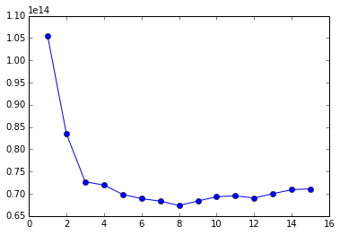

```python
import matplotlib.pyplot as plt
%matplotlib inline

# kvals = range(1, 16)
# plt.plot(kvals, rss_all,'bo-')
plt.plot(kSearch, kOOBRSS,'bo-')
```

```python
kSel = kSearch[np.argmin(kOOBRSS)]
print kSel
```

```
8
```

*QUIZ QUESTION*

What is the RSS on the TEST data using the value of k found above? To be clear, sum over all houses in the TEST set.

```python
NewRSS = np.sum((getQrysKNNPredictions(kSel, glbObsFit_feats, glbObsFit_rsp, \
                                       glbObsNew_feats) -
                 glbObsNew_rsp) ** 2)
print NewRSS
```

```
1.33118823552e+14
```